# DATS6101 Project 1 RMD

Sayra Moore, Andrea Piolini, Sabina Shahbazzade, Caroline Sklaver, Spencer Staub

10/13/2019

## Data File

This data file was retrieved from https://www.kaggle.com/heesoo37/120-years-of-olympic-history-athletes-and-results ‘NOC’ is the name of country, Medal with ‘NA’ value indicates athelete who did not win medal. We will be using only Summer Olympics data to narrow our questions and findings.

```
## 'data.frame':    271116 obs. of  15 variables:
##  $ ID    : int  1 2 3 4 5 5 5 5 5 5 ...
##  $ Name  : Factor w/ 134732 levels "  Gabrielle Marie \"Gabby\" Adcock (White-)",..: 8 9 44318 29412 21469 21469 21469 21469 21469 21469 ...
##  $ Sex   : Factor w/ 2 levels "F","M": 2 2 2 2 1 1 1 1 1 1 ...
##  $ Age   : int  24 23 24 34 21 21 25 25 27 27 ...
##  $ Height: int  180 170 NA NA 185 185 185 185 185 185 ...
##  $ Weight: num  80 60 NA NA 82 82 82 82 82 82 ...
##  $ Team  : Factor w/ 1184 levels "30. Februar",..: 199 199 273 278 705 705 705 705 705 705 ...
##  $ NOC   : Factor w/ 230 levels "AFG","AHO","ALB",..: 42 42 56 56 146 146 146 146 146 146 ...
##  $ Games : Factor w/ 51 levels "1896 Summer",..: 38 49 7 2 37 37 39 39 40 40 ...
##  $ Year  : int  1992 2012 1920 1900 1988 1988 1992 1992 1994 1994 ...
##  $ Season: Factor w/ 2 levels "Summer","Winter": 1 1 1 1 2 2 2 2 2 2 ...
##  $ City  : Factor w/ 42 levels "Albertville",..: 6 18 3 27 9 9 1 1 17 17 ...
##  $ Sport : Factor w/ 66 levels "Aeronautics",..: 9 33 25 62 54 54 54 54 54 54 ...
##  $ Event : Factor w/ 765 levels "Aeronautics Mixed Aeronautics",..: 160 398 349 710 623 619 623 619 623 619 ...
##  $ Medal : Factor w/ 3 levels "Bronze","Gold",..: NA NA NA 2 NA NA NA NA NA NA ...
```

## Descriptive Statistics

### Medals

Graphical representation of top countries total medals earned by medal type. This clearly shows teams that have dominated the 29 Olympic games. Additionally total number of medals earned by men vs. women. Women have earned fewer medals because the number of women athletes competing has trailed that of men (see athlete participation visual below).

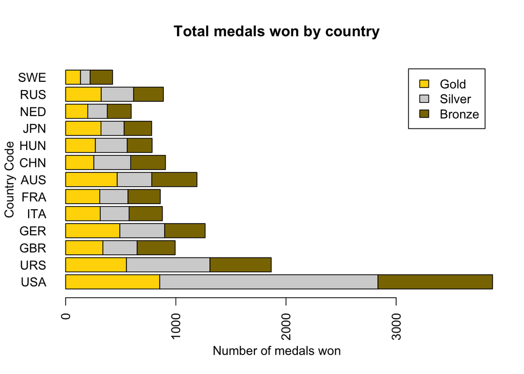

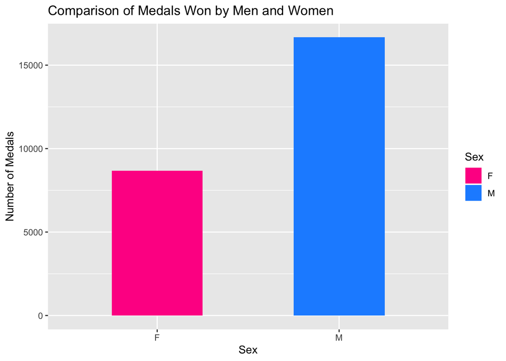

## Athletes Participation Over 120 Years of Summer Olympic Games

Graphical representation of number of athletes over the 120 years of Olympics. Additionally, graph of male and female athlete participation over time to visualize the difference in participation by gender. Female participation has almost matched that of males with increasing numebr of female althletes at almost every game. Additional bar graphs to show popularity of sports both overall and differences in Male/Female.

[figure not shown]

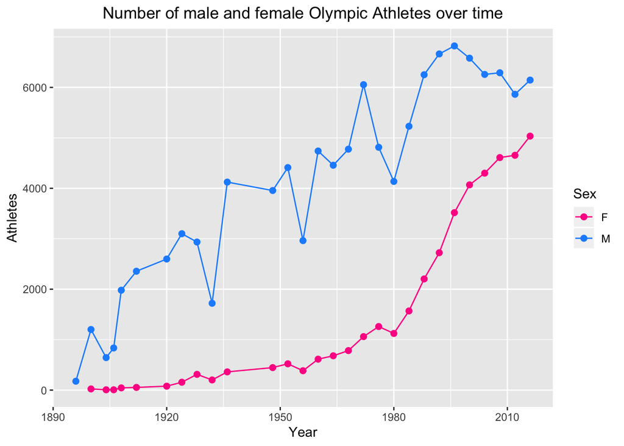

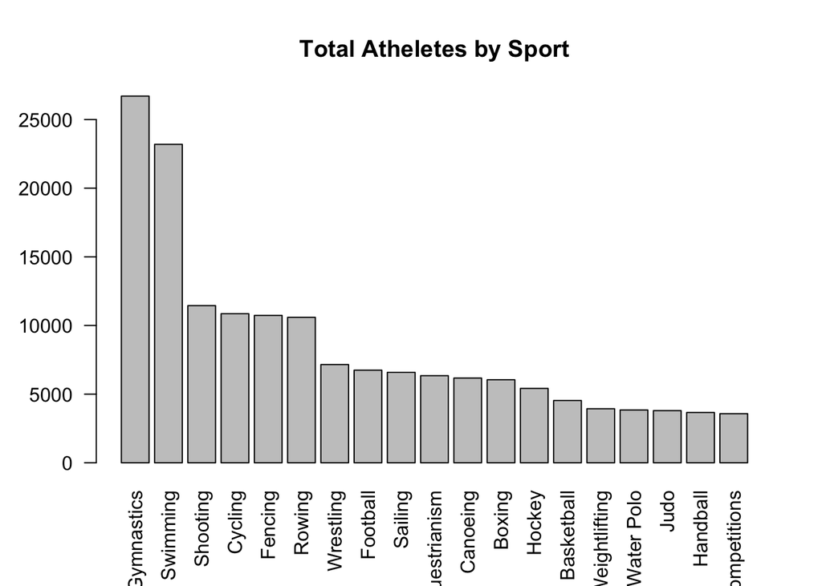

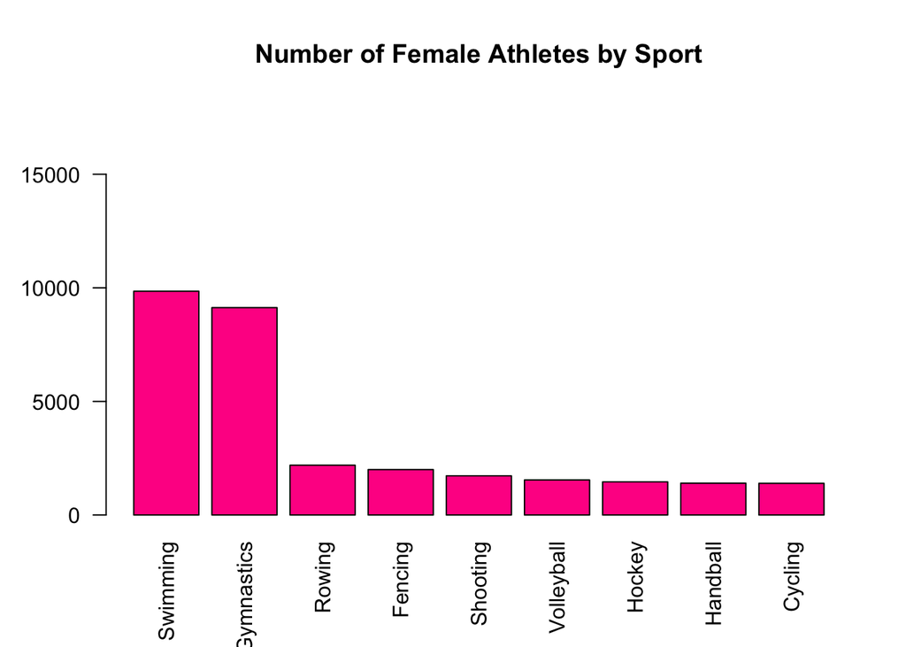

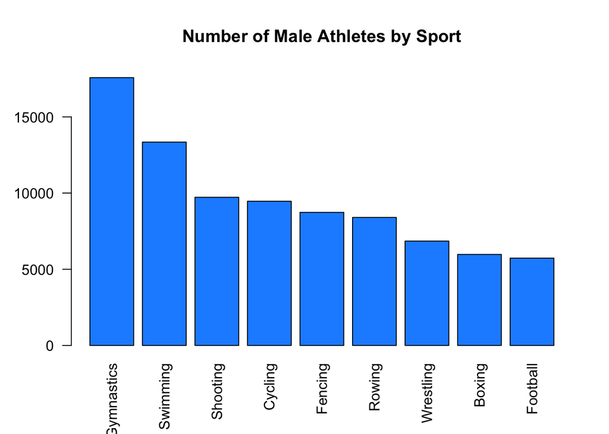

# Age, Height, Weight

Histograms to view the distribution of Age, Height, and Weight for all Olympic Athletes. This is useful to determine the distribution. Age and weight are a bit right-skewed, height is very normal. These distributions do not vary greatly when looking at males and females separately.

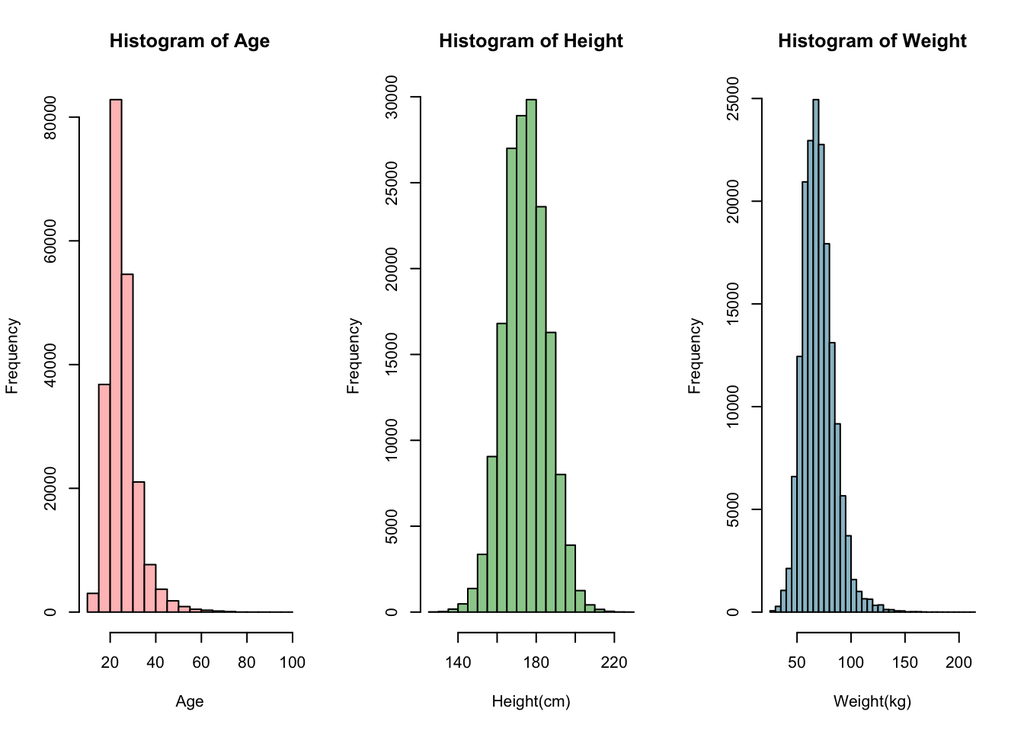

Correlations between age, height, and weight, also represented in graphics. Height and weight are highly correlated (0.7951830).

```
##              Age    Height    Weight
## Age    1.0000000 0.1394187 0.2110977
## Height 0.1394187 1.0000000 0.7951830
## Weight 0.2110977 0.7951830 1.0000000
```

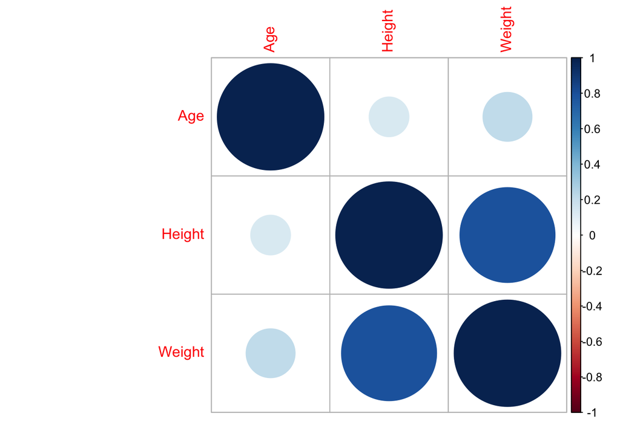

## Statistical Tests

### Does age, height, or weight determine outcome (winning of medals)?

Chi-squared tests in which the null hypothesis is that age, height, and weight do not have a significant effect on whether athletes won a medal or not.These tests resulted in p-values <0.05 meaning we can reject the null hypotheses and conclude that age, height, and weight all determine whether athletes win medals. The age, height, and weight data was made categorical into intervals based on quartiles and mean of each variable.

```
##    Min. 1st Qu.  Median    Mean 3rd Qu.    Max.    NA's
##   10.00   21.00   24.00   25.67   28.00   97.00    9189
```

```
##    Min. 1st Qu.  Median    Mean 3rd Qu.    Max.    NA's
##   127.0   168.0   175.0   175.5   183.0   226.0   51857
```

```
##    Min. 1st Qu.  Median    Mean 3rd Qu.    Max.    NA's
##   25.00   60.00   70.00   70.69   79.00  214.00   53854
```

```
##
##  Pearson's Chi-squared test
##
## data:  cont_age_medal_w_na
## X-squared = 407.17, df = 2, p-value < 2.2e-16
```

```
##
##  Pearson's Chi-squared test
##
## data:  cont_height_medal_w_na
## X-squared = 1261.9, df = 2, p-value < 2.2e-16
```

```
##
##  Pearson's Chi-squared test
##
## data:  cont_weight_medal_w_na
## X-squared = 1259.2, df = 2, p-value < 2.2e-16
```

### Does the average age vary between men and women?

Performed a 2-sample t-test to determine whether the mean age of men significantly differs from that of women. Null hypothesis is that the two means do not differ. With p-value < 0.05, we reject the null hypothesis and conclude that the average age of men and women significantly differs in summer Olympic athletes.

```
##
##  Welch Two Sample t-test
##
## data:  m$Age and f$Age
## t = 91.929, df = 118950, p-value < 2.2e-16
## alternative hypothesis: true difference in means is not equal to 0
## 95 percent confidence interval:
##  2.723613 2.842281
## sample estimates:
## mean of x mean of y
##  26.44394  23.66100
```

### Does age, height, and weight significantly change over the years?

```
##                 Df   Sum Sq Mean Sq F value Pr(>F)
## Year            28   452163   16149   171.7 <2e-16 ***
## Residuals   113296 10658736      94
## ---
## Signif. codes:  0 '***' 0.001 '**' 0.01 '*' 0.05 '.' 0.1 ' ' 1
```

```
##                Df  Sum Sq Mean Sq F value Pr(>F)
## Year           22  157060    7139   85.42 <2e-16 ***
## Residuals   53358 4459645      84
## ---
## Signif. codes:  0 '***' 0.001 '**' 0.01 '*' 0.05 '.' 0.1 ' ' 1
```

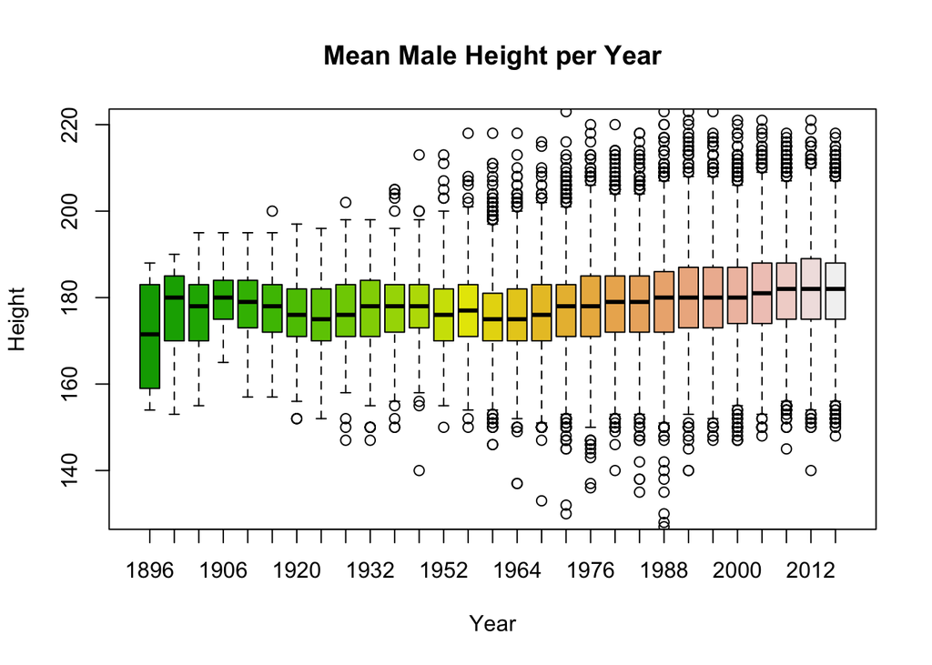

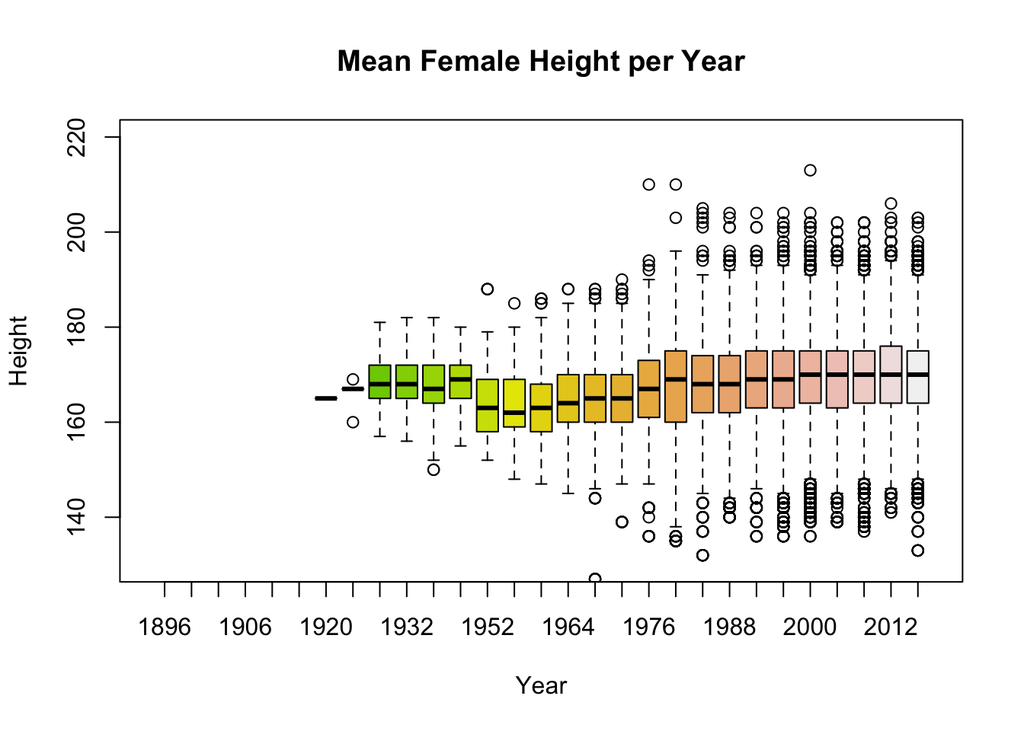

```
##                 Df  Sum Sq Mean Sq F value Pr(>F)
## Year            28   51483  1838.7    61.5 <2e-16 ***
## Residuals   113296 3387142    29.9
## ---
## Signif. codes:  0 '***' 0.001 '**' 0.01 '*' 0.05 '.' 0.1 ' ' 1
```

```
##                Df  Sum Sq Mean Sq F value Pr(>F)
## Year           22  155311    7060   234.8 <2e-16 ***
## Residuals   53358 1604087      30
## ---
## Signif. codes:  0 '***' 0.001 '**' 0.01 '*' 0.05 '.' 0.1 ' ' 1
```

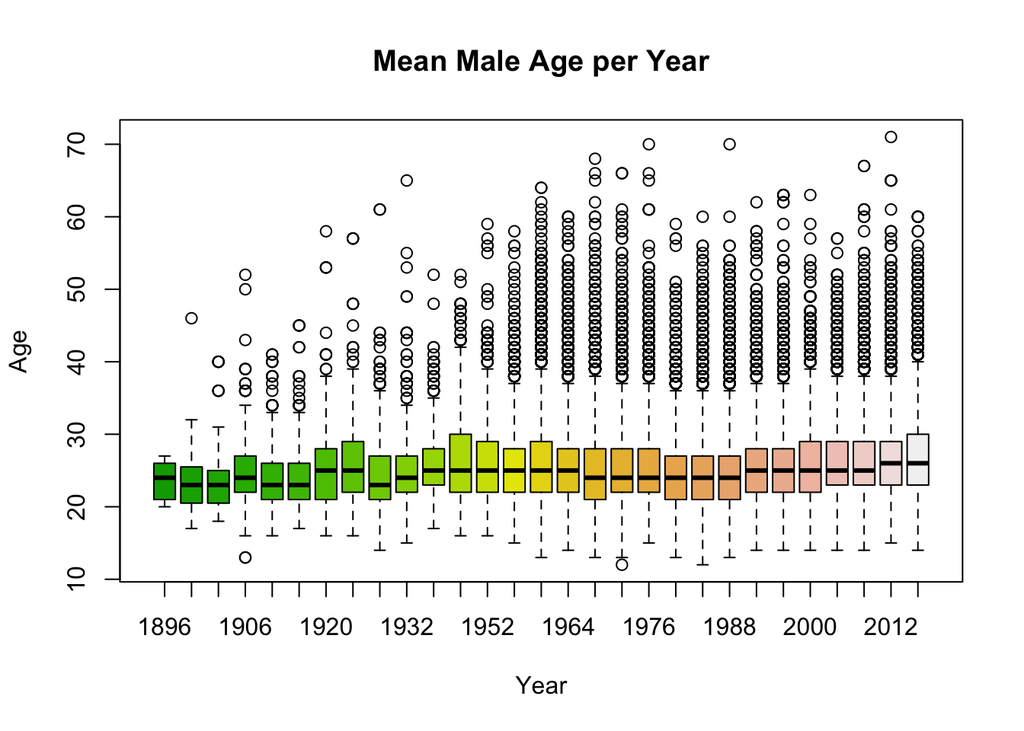

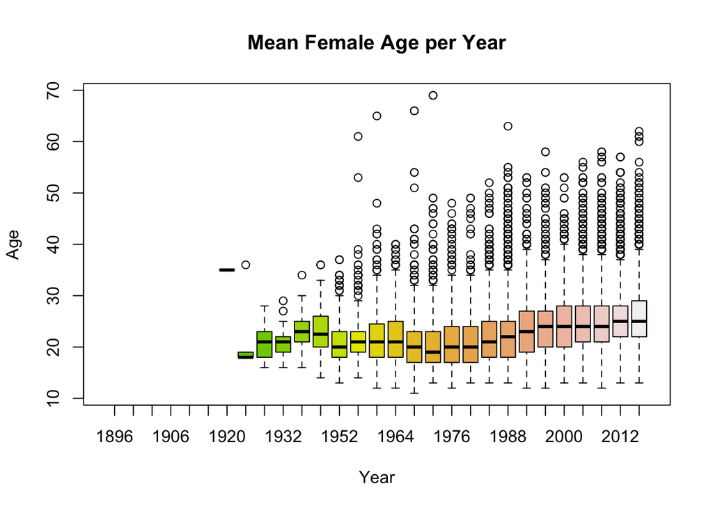

```
##                 Df   Sum Sq Mean Sq F value Pr(>F)
## Year            28   649084   23182   126.3 <2e-16 ***
## Residuals   113296 20792048     184
## ---
## Signif. codes:  0 '***' 0.001 '**' 0.01 '*' 0.05 '.' 0.1 ' ' 1
```

```
##                Df  Sum Sq Mean Sq F value Pr(>F)
## Year           22  156875    7131   62.08 <2e-16 ***
## Residuals   53358 6129093     115
## ---
## Signif. codes:  0 '***' 0.001 '**' 0.01 '*' 0.05 '.' 0.1 ' ' 1
```

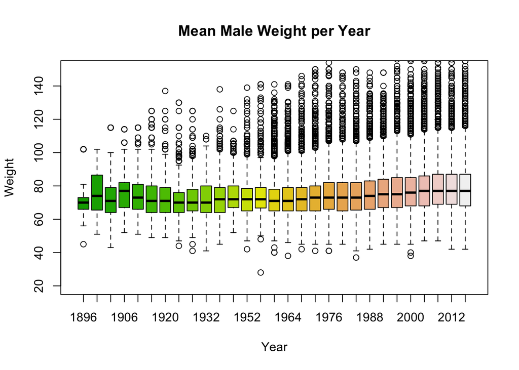

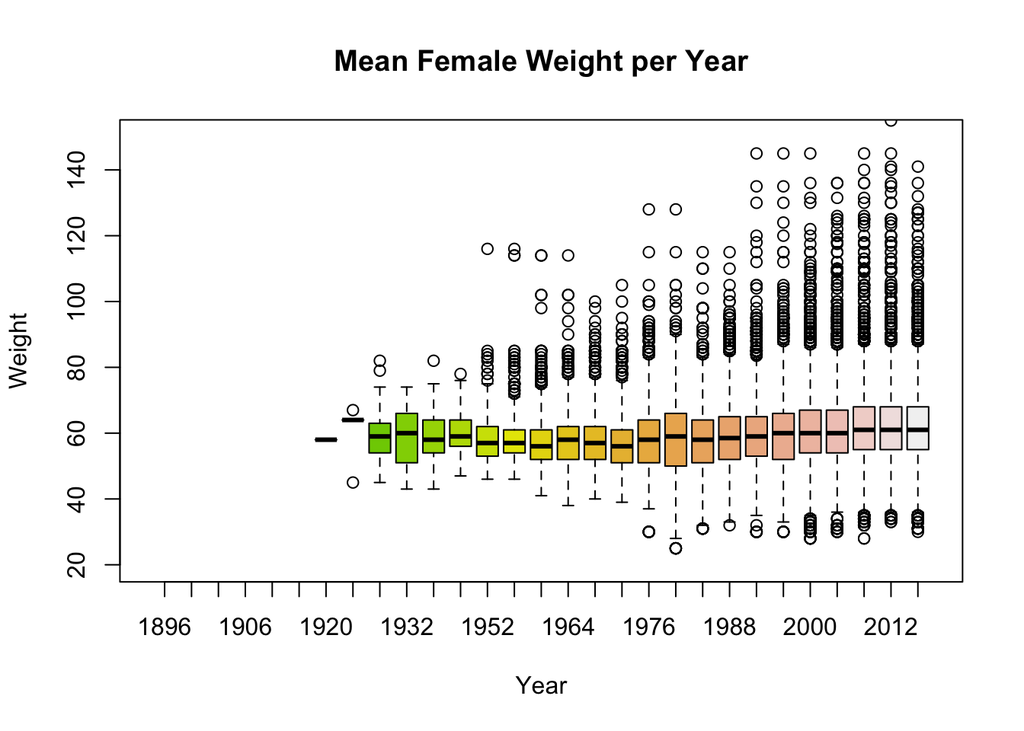